# Optimal Treatment Analysis

## Outcome Variable

**Outcome Variable:** haz

## Predictor Variables

**Intervention Variable:** hhwealth_quart

**Adjustment Set:**

- arm
- sex
- W_mage
- meducyrs
- feducyrs
- W_gagebrth
- W_birthwt
- W_birthlen
- W_nchldlt5
- W_parity
- delta_W_mage
- delta_meducyrs
- delta_feducyrs
- delta_W_gagebrth
- delta_W_birthwt
- delta_W_birthlen
- delta_W_nchldlt5
- delta_W_parity

## Stratifying Variables

The analysis was stratified on these variable(s):

- agecat
- studyid
- country

## Data Summary

| agecat | studyid | country | hhwealth_quart | n_cell | n |
| --- | --- | --- | --- | --- | --- |
| Birth | ki0047075b-MAL-ED | BANGLADESH | Wealth Q4 | 56 | 213 |
| Birth | ki0047075b-MAL-ED | BANGLADESH | Wealth Q1 | 52 | 213 |
| Birth | ki0047075b-MAL-ED | BANGLADESH | Wealth Q2 | 51 | 213 |
| Birth | ki0047075b-MAL-ED | BANGLADESH | Wealth Q3 | 54 | 213 |
| Birth | ki0047075b-MAL-ED | BRAZIL | Wealth Q4 | 11 | 60 |
| Birth | ki0047075b-MAL-ED | BRAZIL | Wealth Q1 | 21 | 60 |
| Birth | ki0047075b-MAL-ED | BRAZIL | Wealth Q2 | 17 | 60 |
| Birth | ki0047075b-MAL-ED | BRAZIL | Wealth Q3 | 11 | 60 |
| Birth | ki0047075b-MAL-ED | INDIA | Wealth Q4 | 8 | 41 |
| Birth | ki0047075b-MAL-ED | INDIA | Wealth Q1 | 14 | 41 |
| Birth | ki0047075b-MAL-ED | INDIA | Wealth Q2 | 9 | 41 |
| Birth | ki0047075b-MAL-ED | INDIA | Wealth Q3 | 10 | 41 |
| Birth | ki0047075b-MAL-ED | NEPAL | Wealth Q4 | 6 | 26 |
| Birth | ki0047075b-MAL-ED | NEPAL | Wealth Q1 | 9 | 26 |
| Birth | ki0047075b-MAL-ED | NEPAL | Wealth Q2 | 3 | 26 |
| Birth | ki0047075b-MAL-ED | NEPAL | Wealth Q3 | 8 | 26 |
| Birth | ki0047075b-MAL-ED | PERU | Wealth Q4 | 54 | 215 |
| Birth | ki0047075b-MAL-ED | PERU | Wealth Q1 | 55 | 215 |
| Birth | ki0047075b-MAL-ED | PERU | Wealth Q2 | 54 | 215 |
| Birth | ki0047075b-MAL-ED | PERU | Wealth Q3 | 52 | 215 |
| Birth | ki0047075b-MAL-ED | SOUTH AFRICA | Wealth Q4 | 17 | 96 |
| Birth | ki0047075b-MAL-ED | SOUTH AFRICA | Wealth Q1 | 27 | 96 |
| Birth | ki0047075b-MAL-ED | SOUTH AFRICA | Wealth Q2 | 24 | 96 |
| Birth | ki0047075b-MAL-ED | SOUTH AFRICA | Wealth Q3 | 28 | 96 |
| Birth | ki0047075b-MAL-ED | TANZANIA, UNITED REPUBLIC OF | Wealth Q4 | 26 | 120 |
| Birth | ki0047075b-MAL-ED | TANZANIA, UNITED REPUBLIC OF | Wealth Q1 | 28 | 120 |
| Birth | ki0047075b-MAL-ED | TANZANIA, UNITED REPUBLIC OF | Wealth Q2 | 32 | 120 |
| Birth | ki0047075b-MAL-ED | TANZANIA, UNITED REPUBLIC OF | Wealth Q3 | 34 | 120 |
| Birth | ki1000108-CMC-V-BCS-2002 | INDIA | Wealth Q4 | 32 | 92 |
| Birth | ki1000108-CMC-V-BCS-2002 | INDIA | Wealth Q1 | 15 | 92 |

[output cut: 178 more lines]

The following strata were considered:

- agecat: 24 months, studyid: ki0047075b-MAL-ED, country: BANGLADESH
- agecat: 24 months, studyid: ki0047075b-MAL-ED, country: BRAZIL
- agecat: 24 months, studyid: ki0047075b-MAL-ED, country: INDIA
- agecat: 24 months, studyid: ki0047075b-MAL-ED, country: NEPAL
- agecat: 24 months, studyid: ki0047075b-MAL-ED, country: PERU
- agecat: 24 months, studyid: ki0047075b-MAL-ED, country: SOUTH AFRICA
- agecat: 24 months, studyid: ki0047075b-MAL-ED, country: TANZANIA, UNITED REPUBLIC OF
- agecat: 24 months, studyid: ki1000108-CMC-V-BCS-2002, country: INDIA
- agecat: 24 months, studyid: ki1000108-IRC, country: INDIA
- agecat: 24 months, studyid: ki1017093b-PROVIDE, country: BANGLADESH
- agecat: 24 months, studyid: ki1066203-TanzaniaChild2, country: TANZANIA, UNITED REPUBLIC OF
- agecat: 24 months, studyid: ki1113344-GMS-Nepal, country: NEPAL
- agecat: 24 months, studyid: ki1114097-CONTENT, country: PERU
- agecat: 24 months, studyid: ki1135781-COHORTS, country: GUATEMALA
- agecat: 24 months, studyid: ki1135781-COHORTS, country: PHILIPPINES
- agecat: 24 months, studyid: ki1148112-LCNI-5, country: MALAWI
- agecat: 24 months, studyid: kiGH5241-JiVitA-3, country: BANGLADESH
- agecat: 24 months, studyid: kiGH5241-JiVitA-4, country: BANGLADESH
- agecat: 6 months, studyid: ki0047075b-MAL-ED, country: BANGLADESH
- agecat: 6 months, studyid: ki0047075b-MAL-ED, country: BRAZIL
- agecat: 6 months, studyid: ki0047075b-MAL-ED, country: INDIA
- agecat: 6 months, studyid: ki0047075b-MAL-ED, country: NEPAL
- agecat: 6 months, studyid: ki0047075b-MAL-ED, country: PERU
- agecat: 6 months, studyid: ki0047075b-MAL-ED, country: SOUTH AFRICA
- agecat: 6 months, studyid: ki0047075b-MAL-ED, country: TANZANIA, UNITED REPUBLIC OF
- agecat: 6 months, studyid: ki1000108-CMC-V-BCS-2002, country: INDIA
- agecat: 6 months, studyid: ki1000108-IRC, country: INDIA
- agecat: 6 months, studyid: ki1017093b-PROVIDE, country: BANGLADESH
- agecat: 6 months, studyid: ki1066203-TanzaniaChild2, country: TANZANIA, UNITED REPUBLIC OF
- agecat: 6 months, studyid: ki1113344-GMS-Nepal, country: NEPAL
- agecat: 6 months, studyid: ki1114097-CONTENT, country: PERU
- agecat: 6 months, studyid: ki1135781-COHORTS, country: GUATEMALA
- agecat: 6 months, studyid: ki1135781-COHORTS, country: PHILIPPINES
- agecat: 6 months, studyid: ki1148112-LCNI-5, country: MALAWI
- agecat: 6 months, studyid: kiGH5241-JiVitA-3, country: BANGLADESH
- agecat: 6 months, studyid: kiGH5241-JiVitA-4, country: BANGLADESH
- agecat: Birth, studyid: ki0047075b-MAL-ED, country: BANGLADESH
- agecat: Birth, studyid: ki0047075b-MAL-ED, country: BRAZIL
- agecat: Birth, studyid: ki0047075b-MAL-ED, country: INDIA
- agecat: Birth, studyid: ki0047075b-MAL-ED, country: NEPAL
- agecat: Birth, studyid: ki0047075b-MAL-ED, country: PERU
- agecat: Birth, studyid: ki0047075b-MAL-ED, country: SOUTH AFRICA
- agecat: Birth, studyid: ki0047075b-MAL-ED, country: TANZANIA, UNITED REPUBLIC OF
- agecat: Birth, studyid: ki1000108-CMC-V-BCS-2002, country: INDIA
- agecat: Birth, studyid: ki1000108-IRC, country: INDIA
- agecat: Birth, studyid: ki1017093b-PROVIDE, country: BANGLADESH
- agecat: Birth, studyid: ki1113344-GMS-Nepal, country: NEPAL
- agecat: Birth, studyid: ki1114097-CONTENT, country: PERU
- agecat: Birth, studyid: ki1135781-COHORTS, country: GUATEMALA
- agecat: Birth, studyid: ki1135781-COHORTS, country: PHILIPPINES
- agecat: Birth, studyid: kiGH5241-JiVitA-3, country: BANGLADESH
- agecat: Birth, studyid: kiGH5241-JiVitA-4, country: BANGLADESH

### Dropped Strata

Some strata were dropped due to rare outcomes:

- agecat: Birth, studyid: ki0047075b-MAL-ED, country: NEPAL
- agecat: Birth, studyid: ki1114097-CONTENT, country: PERU
- agecat: 24 months, studyid: ki1066203-TanzaniaChild2, country: TANZANIA, UNITED REPUBLIC OF

## Methods Detail

We’re interested in the causal parameters $E[Y_a]$ for all values of $a \in \mathcal{A}$. These parameters represent the mean outcome if, possibly contrary to fact, we intervened to set all units to have $A=a$. Under the randomization and positivity assumptions, these are identified by the statistical parameters $\psi_a=E_W[E_{Y|A,W}(Y|A=a,W)]$. In addition, we’re interested in the mean of $Y$, $E[Y]$ under no intervention (the observed mean). We will estimate these parameters by using SuperLearner to fit the relevant likelihood factors – $E_{Y|A,W}(Y|A=a,W)$ and $p(A=a|W)$, and then updating our likelihood fit using a joint TMLE.

For unadjusted analyses ($W=\{\}$), initial likelihoods were estimated using Lrnr_glm to estimate the simple $E(Y|A)$ and Lrnr_mean to estimate $p(A)$. For adjusted analyses, a small library containing Lrnr_glmnet, Lrnr_xgboost, and Lrnr_mean was used.

Having estimated these parameters, we will then use the delta method to estimate relative risks and attributable risks relative to a prespecified baseline level of $A$.

# Results Detail

## Results Plots

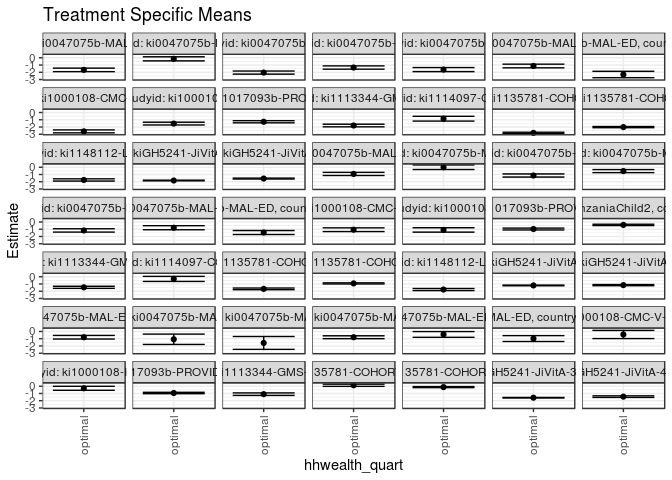

## Results Table

### Parameter: TSM

| agecat | studyid | country | intervention_level | baseline_level | estimate | ci_lower | ci_upper |
| --- | --- | --- | --- | --- | --- | --- | --- |
| Birth | ki0047075b-MAL-ED | BANGLADESH | optimal | observed | -0.7941642 | -1.0420455 | -0.5462828 |
| Birth | ki0047075b-MAL-ED | BRAZIL | optimal | observed | -1.0758123 | -1.7873913 | -0.3642333 |
| Birth | ki0047075b-MAL-ED | INDIA | optimal | observed | -1.5810878 | -2.4706853 | -0.6914903 |
| Birth | ki0047075b-MAL-ED | PERU | optimal | observed | -0.7936498 | -0.9913688 | -0.5959307 |
| Birth | ki0047075b-MAL-ED | SOUTH AFRICA | optimal | observed | -0.4065900 | -0.8021578 | -0.0110223 |
| Birth | ki0047075b-MAL-ED | TANZANIA, UNITED REPUBLIC OF | optimal | observed | -0.9774532 | -1.3830441 | -0.5718624 |
| Birth | ki1000108-CMC-V-BCS-2002 | INDIA | optimal | observed | -0.4165932 | -0.9799229 | 0.1467366 |
| Birth | ki1000108-IRC | INDIA | optimal | observed | -0.2900789 | -0.5665082 | -0.0136497 |
| Birth | ki1017093b-PROVIDE | BANGLADESH | optimal | observed | -0.9373543 | -1.0362747 | -0.8384338 |
| Birth | ki1113344-GMS-Nepal | NEPAL | optimal | observed | -1.0954731 | -1.2684614 | -0.9224849 |
| Birth | ki1135781-COHORTS | GUATEMALA | optimal | observed | 0.1302238 | -0.0232598 | 0.2837073 |
| Birth | ki1135781-COHORTS | PHILIPPINES | optimal | observed | -0.1234136 | -0.1933131 | -0.0535140 |
| Birth | kiGH5241-JiVitA-3 | BANGLADESH | optimal | observed | -1.5860108 | -1.6191457 | -1.5528760 |
| Birth | kiGH5241-JiVitA-4 | BANGLADESH | optimal | observed | -1.4384987 | -1.5477567 | -1.3292407 |
| 6 months | ki0047075b-MAL-ED | BANGLADESH | optimal | observed | -0.9219169 | -1.1386257 | -0.7052081 |
| 6 months | ki0047075b-MAL-ED | BRAZIL | optimal | observed | 0.0054181 | -0.3090169 | 0.3198531 |
| 6 months | ki0047075b-MAL-ED | INDIA | optimal | observed | -1.1371466 | -1.3529200 | -0.9213732 |
| 6 months | ki0047075b-MAL-ED | NEPAL | optimal | observed | -0.5299282 | -0.7435630 | -0.3162934 |
| 6 months | ki0047075b-MAL-ED | PERU | optimal | observed | -1.1647805 | -1.3963368 | -0.9332242 |
| 6 months | ki0047075b-MAL-ED | SOUTH AFRICA | optimal | observed | -0.7926589 | -1.0720292 | -0.5132886 |
| 6 months | ki0047075b-MAL-ED | TANZANIA, UNITED REPUBLIC OF | optimal | observed | -1.4495105 | -1.7224479 | -1.1765730 |
| 6 months | ki1000108-CMC-V-BCS-2002 | INDIA | optimal | observed | -1.0612193 | -1.3175695 | -0.8048692 |
| 6 months | ki1000108-IRC | INDIA | optimal | observed | -1.0957952 | -1.3994047 | -0.7921857 |
| 6 months | ki1017093b-PROVIDE | BANGLADESH | optimal | observed | -0.9677212 | -1.0963727 | -0.8390698 |
| 6 months | ki1066203-TanzaniaChild2 | TANZANIA, UNITED REPUBLIC OF | optimal | observed | -0.4021160 | -0.4932383 | -0.3109936 |
| 6 months | ki1113344-GMS-Nepal | NEPAL | optimal | observed | -1.4613108 | -1.6074336 | -1.3151881 |
| 6 months | ki1114097-CONTENT | PERU | optimal | observed | -0.2983903 | -0.6490442 | 0.0522637 |
| 6 months | ki1135781-COHORTS | GUATEMALA | optimal | observed | -1.6756662 | -1.7895807 | -1.5617516 |
| 6 months | ki1135781-COHORTS | PHILIPPINES | optimal | observed | -0.9204493 | -1.0006880 | -0.8402106 |
| 6 months | ki1148112-LCNI-5 | MALAWI | optimal | observed | -1.7657328 | -1.9062545 | -1.6252111 |
| 6 months | kiGH5241-JiVitA-3 | BANGLADESH | optimal | observed | -1.1999622 | -1.2400928 | -1.1598316 |
| 6 months | kiGH5241-JiVitA-4 | BANGLADESH | optimal | observed | -1.1600762 | -1.2345123 | -1.0856402 |
| 24 months | ki0047075b-MAL-ED | BANGLADESH | optimal | observed | -1.6681344 | -1.9081037 | -1.4281652 |
| 24 months | ki0047075b-MAL-ED | BRAZIL | optimal | observed | -0.1431495 | -0.4244983 | 0.1381993 |
| 24 months | ki0047075b-MAL-ED | INDIA | optimal | observed | -2.0406408 | -2.2556415 | -1.8256400 |
| 24 months | ki0047075b-MAL-ED | NEPAL | optimal | observed | -1.3442582 | -1.5677695 | -1.1207470 |
| 24 months | ki0047075b-MAL-ED | PERU | optimal | observed | -1.6265927 | -1.9056592 | -1.3475262 |
| 24 months | ki0047075b-MAL-ED | SOUTH AFRICA | optimal | observed | -1.1338591 | -1.3850265 | -0.8826916 |
| 24 months | ki0047075b-MAL-ED | TANZANIA, UNITED REPUBLIC OF | optimal | observed | -2.3102089 | -2.7499067 | -1.8705111 |
| 24 months | ki1000108-CMC-V-BCS-2002 | INDIA | optimal | observed | -2.5999929 | -2.8008254 | -2.3991604 |
| 24 months | ki1000108-IRC | INDIA | optimal | observed | -1.5251179 | -1.7156839 | -1.3345519 |
| 24 months | ki1017093b-PROVIDE | BANGLADESH | optimal | observed | -1.2747269 | -1.4233131 | -1.1261406 |
| 24 months | ki1113344-GMS-Nepal | NEPAL | optimal | observed | -1.7924782 | -1.9751013 | -1.6098551 |
| 24 months | ki1114097-CONTENT | PERU | optimal | observed | -0.8507448 | -1.1818041 | -0.5196855 |
| 24 months | ki1135781-COHORTS | GUATEMALA | optimal | observed | -2.8133259 | -2.9099025 | -2.7167493 |
| 24 months | ki1135781-COHORTS | PHILIPPINES | optimal | observed | -2.0104901 | -2.0933991 | -1.9275811 |
| 24 months | ki1148112-LCNI-5 | MALAWI | optimal | observed | -1.7516379 | -1.9040019 | -1.5992738 |
| 24 months | kiGH5241-JiVitA-3 | BANGLADESH | optimal | observed | -1.8283125 | -1.8752599 | -1.7813651 |
| 24 months | kiGH5241-JiVitA-4 | BANGLADESH | optimal | observed | -1.5588735 | -1.6248264 | -1.4929205 |

### Parameter: E(Y)

| agecat | studyid | country | intervention_level | baseline_level | estimate | ci_lower | ci_upper |
| --- | --- | --- | --- | --- | --- | --- | --- |
| Birth | ki0047075b-MAL-ED | BANGLADESH | observed | observed | -1.0530516 | -1.1896058 | -0.9164975 |
| Birth | ki0047075b-MAL-ED | BRAZIL | observed | observed | -0.6963333 | -0.9881882 | -0.4044785 |
| Birth | ki0047075b-MAL-ED | INDIA | observed | observed | -1.2070732 | -1.5254820 | -0.8886644 |
| Birth | ki0047075b-MAL-ED | PERU | observed | observed | -0.9141395 | -1.0364098 | -0.7918693 |
| Birth | ki0047075b-MAL-ED | SOUTH AFRICA | observed | observed | -0.5523958 | -0.7550074 | -0.3497843 |
| Birth | ki0047075b-MAL-ED | TANZANIA, UNITED REPUBLIC OF | observed | observed | -1.1225000 | -1.3335666 | -0.9114334 |
| Birth | ki1000108-CMC-V-BCS-2002 | INDIA | observed | observed | -0.9611957 | -1.1776967 | -0.7446946 |
| Birth | ki1000108-IRC | INDIA | observed | observed | -0.3080412 | -0.4687931 | -0.1472894 |
| Birth | ki1017093b-PROVIDE | BANGLADESH | observed | observed | -0.8851020 | -0.9601332 | -0.8100709 |
| Birth | ki1113344-GMS-Nepal | NEPAL | observed | observed | -1.0851580 | -1.1651811 | -1.0051350 |
| Birth | ki1135781-COHORTS | GUATEMALA | observed | observed | 0.1452941 | 0.0610109 | 0.2295774 |
| Birth | ki1135781-COHORTS | PHILIPPINES | observed | observed | -0.2491505 | -0.2881717 | -0.2101294 |
| Birth | kiGH5241-JiVitA-3 | BANGLADESH | observed | observed | -1.5897094 | -1.6089856 | -1.5704331 |
| Birth | kiGH5241-JiVitA-4 | BANGLADESH | observed | observed | -1.5236135 | -1.5727559 | -1.4744711 |
| 6 months | ki0047075b-MAL-ED | BANGLADESH | observed | observed | -1.2026806 | -1.3203025 | -1.0850586 |
| 6 months | ki0047075b-MAL-ED | BRAZIL | observed | observed | 0.0475758 | -0.0963508 | 0.1915023 |
| 6 months | ki0047075b-MAL-ED | INDIA | observed | observed | -1.2070638 | -1.3255909 | -1.0885368 |
| 6 months | ki0047075b-MAL-ED | NEPAL | observed | observed | -0.5615819 | -0.6741832 | -0.4489807 |
| 6 months | ki0047075b-MAL-ED | PERU | observed | observed | -1.3248549 | -1.4336721 | -1.2160378 |
| 6 months | ki0047075b-MAL-ED | SOUTH AFRICA | observed | observed | -1.0547925 | -1.1843544 | -0.9252306 |
| 6 months | ki0047075b-MAL-ED | TANZANIA, UNITED REPUBLIC OF | observed | observed | -1.3687449 | -1.4907629 | -1.2467270 |
| 6 months | ki1000108-CMC-V-BCS-2002 | INDIA | observed | observed | -1.4234508 | -1.5645974 | -1.2823042 |
| 6 months | ki1000108-IRC | INDIA | observed | observed | -1.2344062 | -1.3658524 | -1.1029600 |
| 6 months | ki1017093b-PROVIDE | BANGLADESH | observed | observed | -1.0916915 | -1.1661176 | -1.0172654 |
| 6 months | ki1066203-TanzaniaChild2 | TANZANIA, UNITED REPUBLIC OF | observed | observed | -0.5442232 | -0.5932373 | -0.4952090 |
| 6 months | ki1113344-GMS-Nepal | NEPAL | observed | observed | -1.3508392 | -1.4290633 | -1.2726152 |
| 6 months | ki1114097-CONTENT | PERU | observed | observed | -0.3139217 | -0.4868486 | -0.1409948 |
| 6 months | ki1135781-COHORTS | GUATEMALA | observed | observed | -1.8112324 | -1.8807284 | -1.7417365 |
| 6 months | ki1135781-COHORTS | PHILIPPINES | observed | observed | -1.1405724 | -1.1824954 | -1.0986493 |
| 6 months | ki1148112-LCNI-5 | MALAWI | observed | observed | -1.6426961 | -1.7120603 | -1.5733318 |
| 6 months | kiGH5241-JiVitA-3 | BANGLADESH | observed | observed | -1.3132090 | -1.3363486 | -1.2900693 |
| 6 months | kiGH5241-JiVitA-4 | BANGLADESH | observed | observed | -1.3440477 | -1.3813060 | -1.3067894 |
| 24 months | ki0047075b-MAL-ED | BANGLADESH | observed | observed | -1.9783962 | -2.1050210 | -1.8517715 |
| 24 months | ki0047075b-MAL-ED | BRAZIL | observed | observed | 0.0061144 | -0.1625850 | 0.1748138 |
| 24 months | ki0047075b-MAL-ED | INDIA | observed | observed | -1.8861894 | -2.0110006 | -1.7613783 |
| 24 months | ki0047075b-MAL-ED | NEPAL | observed | observed | -1.3075877 | -1.4270718 | -1.1881037 |
| 24 months | ki0047075b-MAL-ED | PERU | observed | observed | -1.7524710 | -1.8736426 | -1.6312994 |
| 24 months | ki0047075b-MAL-ED | SOUTH AFRICA | observed | observed | -1.6450595 | -1.7797240 | -1.5103950 |
| 24 months | ki0047075b-MAL-ED | TANZANIA, UNITED REPUBLIC OF | observed | observed | -2.6455607 | -2.7807256 | -2.5103959 |
| 24 months | ki1000108-CMC-V-BCS-2002 | INDIA | observed | observed | -2.5588679 | -2.6583730 | -2.4593629 |
| 24 months | ki1000108-IRC | INDIA | observed | observed | -1.7987775 | -1.8923914 | -1.7051636 |
| 24 months | ki1017093b-PROVIDE | BANGLADESH | observed | observed | -1.6024221 | -1.6857420 | -1.5191023 |
| 24 months | ki1113344-GMS-Nepal | NEPAL | observed | observed | -1.8874180 | -1.9728588 | -1.8019773 |
| 24 months | ki1114097-CONTENT | PERU | observed | observed | -0.6962195 | -0.8674103 | -0.5250287 |
| 24 months | ki1135781-COHORTS | GUATEMALA | observed | observed | -2.9893430 | -3.0546993 | -2.9239867 |
| 24 months | ki1135781-COHORTS | PHILIPPINES | observed | observed | -2.4141145 | -2.4590818 | -2.3691473 |
| 24 months | ki1148112-LCNI-5 | MALAWI | observed | observed | -1.8822648 | -1.9637218 | -1.8008078 |
| 24 months | kiGH5241-JiVitA-3 | BANGLADESH | observed | observed | -2.0135591 | -2.0412422 | -1.9858759 |
| 24 months | kiGH5241-JiVitA-4 | BANGLADESH | observed | observed | -1.7803708 | -1.8158650 | -1.7448765 |

### Parameter: PAR

| agecat | studyid | country | intervention_level | baseline_level | estimate | ci_lower | ci_upper |
| --- | --- | --- | --- | --- | --- | --- | --- |
| Birth | ki0047075b-MAL-ED | BANGLADESH | optimal | observed | -0.2588875 | -0.4796634 | -0.0381115 |
| Birth | ki0047075b-MAL-ED | BRAZIL | optimal | observed | 0.3794790 | -0.2638549 | 1.0228128 |
| Birth | ki0047075b-MAL-ED | INDIA | optimal | observed | 0.3740146 | -0.3501974 | 1.0982266 |
| Birth | ki0047075b-MAL-ED | PERU | optimal | observed | -0.1204898 | -0.2824788 | 0.0414993 |
| Birth | ki0047075b-MAL-ED | SOUTH AFRICA | optimal | observed | -0.1458058 | -0.4776513 | 0.1860397 |
| Birth | ki0047075b-MAL-ED | TANZANIA, UNITED REPUBLIC OF | optimal | observed | -0.1450468 | -0.5053877 | 0.2152942 |
| Birth | ki1000108-CMC-V-BCS-2002 | INDIA | optimal | observed | -0.5446025 | -1.0536010 | -0.0356039 |
| Birth | ki1000108-IRC | INDIA | optimal | observed | -0.0179623 | -0.2497196 | 0.2137950 |
| Birth | ki1017093b-PROVIDE | BANGLADESH | optimal | observed | 0.0522522 | -0.0357993 | 0.1403037 |
| Birth | ki1113344-GMS-Nepal | NEPAL | optimal | observed | 0.0103151 | -0.1317042 | 0.1523343 |
| Birth | ki1135781-COHORTS | GUATEMALA | optimal | observed | 0.0150703 | -0.1138863 | 0.1440270 |
| Birth | ki1135781-COHORTS | PHILIPPINES | optimal | observed | -0.1257370 | -0.1851338 | -0.0663402 |
| Birth | kiGH5241-JiVitA-3 | BANGLADESH | optimal | observed | -0.0036986 | -0.0308767 | 0.0234796 |
| Birth | kiGH5241-JiVitA-4 | BANGLADESH | optimal | observed | -0.0851148 | -0.1782872 | 0.0080575 |
| 6 months | ki0047075b-MAL-ED | BANGLADESH | optimal | observed | -0.2807636 | -0.4727625 | -0.0887648 |
| 6 months | ki0047075b-MAL-ED | BRAZIL | optimal | observed | 0.0421577 | -0.2261647 | 0.3104800 |
| 6 months | ki0047075b-MAL-ED | INDIA | optimal | observed | -0.0699172 | -0.2649707 | 0.1251362 |
| 6 months | ki0047075b-MAL-ED | NEPAL | optimal | observed | -0.0316537 | -0.2216419 | 0.1583345 |
| 6 months | ki0047075b-MAL-ED | PERU | optimal | observed | -0.1600744 | -0.3590426 | 0.0388938 |
| 6 months | ki0047075b-MAL-ED | SOUTH AFRICA | optimal | observed | -0.2621336 | -0.5039101 | -0.0203571 |
| 6 months | ki0047075b-MAL-ED | TANZANIA, UNITED REPUBLIC OF | optimal | observed | 0.0807656 | -0.1474818 | 0.3090129 |
| 6 months | ki1000108-CMC-V-BCS-2002 | INDIA | optimal | observed | -0.3622314 | -0.5937075 | -0.1307554 |
| 6 months | ki1000108-IRC | INDIA | optimal | observed | -0.1386110 | -0.3908075 | 0.1135855 |
| 6 months | ki1017093b-PROVIDE | BANGLADESH | optimal | observed | -0.1239703 | -0.2390187 | -0.0089219 |
| 6 months | ki1066203-TanzaniaChild2 | TANZANIA, UNITED REPUBLIC OF | optimal | observed | -0.1421072 | -0.2171353 | -0.0670792 |
| 6 months | ki1113344-GMS-Nepal | NEPAL | optimal | observed | 0.1104716 | -0.0188791 | 0.2398223 |
| 6 months | ki1114097-CONTENT | PERU | optimal | observed | -0.0155315 | -0.3237750 | 0.2927121 |
| 6 months | ki1135781-COHORTS | GUATEMALA | optimal | observed | -0.1355663 | -0.2328512 | -0.0382814 |
| 6 months | ki1135781-COHORTS | PHILIPPINES | optimal | observed | -0.2201231 | -0.2883682 | -0.1518780 |
| 6 months | ki1148112-LCNI-5 | MALAWI | optimal | observed | 0.1230367 | 0.0014123 | 0.2446612 |
| 6 months | kiGH5241-JiVitA-3 | BANGLADESH | optimal | observed | -0.1132468 | -0.1446975 | -0.0817960 |
| 6 months | kiGH5241-JiVitA-4 | BANGLADESH | optimal | observed | -0.1839714 | -0.2453440 | -0.1225988 |
| 24 months | ki0047075b-MAL-ED | BANGLADESH | optimal | observed | -0.3102618 | -0.5143827 | -0.1061409 |
| 24 months | ki0047075b-MAL-ED | BRAZIL | optimal | observed | 0.1492639 | -0.0967416 | 0.3952694 |
| 24 months | ki0047075b-MAL-ED | INDIA | optimal | observed | 0.1544513 | -0.0398967 | 0.3487993 |
| 24 months | ki0047075b-MAL-ED | NEPAL | optimal | observed | 0.0366705 | -0.1614435 | 0.2347846 |
| 24 months | ki0047075b-MAL-ED | PERU | optimal | observed | -0.1258783 | -0.3594279 | 0.1076713 |
| 24 months | ki0047075b-MAL-ED | SOUTH AFRICA | optimal | observed | -0.5112004 | -0.7323713 | -0.2900296 |
| 24 months | ki0047075b-MAL-ED | TANZANIA, UNITED REPUBLIC OF | optimal | observed | -0.3353518 | -0.7446056 | 0.0739019 |
| 24 months | ki1000108-CMC-V-BCS-2002 | INDIA | optimal | observed | 0.0411250 | -0.1348675 | 0.2171174 |
| 24 months | ki1000108-IRC | INDIA | optimal | observed | -0.2736596 | -0.4389828 | -0.1083364 |
| 24 months | ki1017093b-PROVIDE | BANGLADESH | optimal | observed | -0.3276953 | -0.4572896 | -0.1981009 |
| 24 months | ki1113344-GMS-Nepal | NEPAL | optimal | observed | -0.0949398 | -0.2516378 | 0.0617581 |
| 24 months | ki1114097-CONTENT | PERU | optimal | observed | 0.1545253 | -0.1314324 | 0.4404829 |
| 24 months | ki1135781-COHORTS | GUATEMALA | optimal | observed | -0.1760171 | -0.2549973 | -0.0970369 |
| 24 months | ki1135781-COHORTS | PHILIPPINES | optimal | observed | -0.4036245 | -0.4754384 | -0.3318105 |
| 24 months | ki1148112-LCNI-5 | MALAWI | optimal | observed | -0.1306269 | -0.2609484 | -0.0003055 |
| 24 months | kiGH5241-JiVitA-3 | BANGLADESH | optimal | observed | -0.1852466 | -0.2229605 | -0.1475327 |
| 24 months | kiGH5241-JiVitA-4 | BANGLADESH | optimal | observed | -0.2214973 | -0.2753603 | -0.1676343 |